# Reproducible Research: Peer Assessment 1

## Loading and preprocessing the data

```r
activity <- read.csv("./data/activity.csv")
```

## What is mean total number of steps taken per day?

**Make a histogram of the total number of steps taken each day**

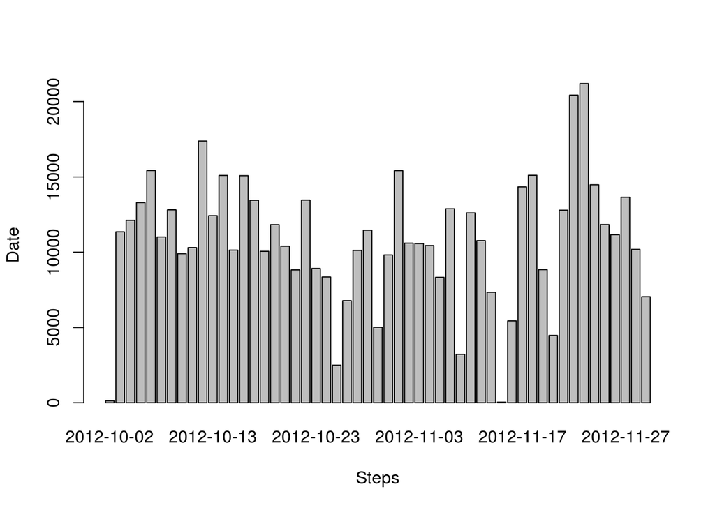

```r
stepsPerDay <- aggregate(steps ~ date, data = activity, FUN = sum)
barplot(stepsPerDay$steps, names.arg = stepsPerDay$date, xlab = "Steps", ylab = "Date")
```

```r
png(filename = "./plot1.png", width = 480, height = 480, units = "px", bg = "white")
dev.off()
```

**Calculate and report the mean and median total number of steps taken per day**

```r
mean(stepsPerDay$steps)
```

```
## [1] 10766
```

```r
median(stepsPerDay$steps)
```

```
## [1] 10765
```

## What is the average daily activity pattern?

**Make a time series plot (i.e. type = “l”) of the 5-minute interval (x-axis) and the average number of steps taken, averaged across all days (y-axis)**

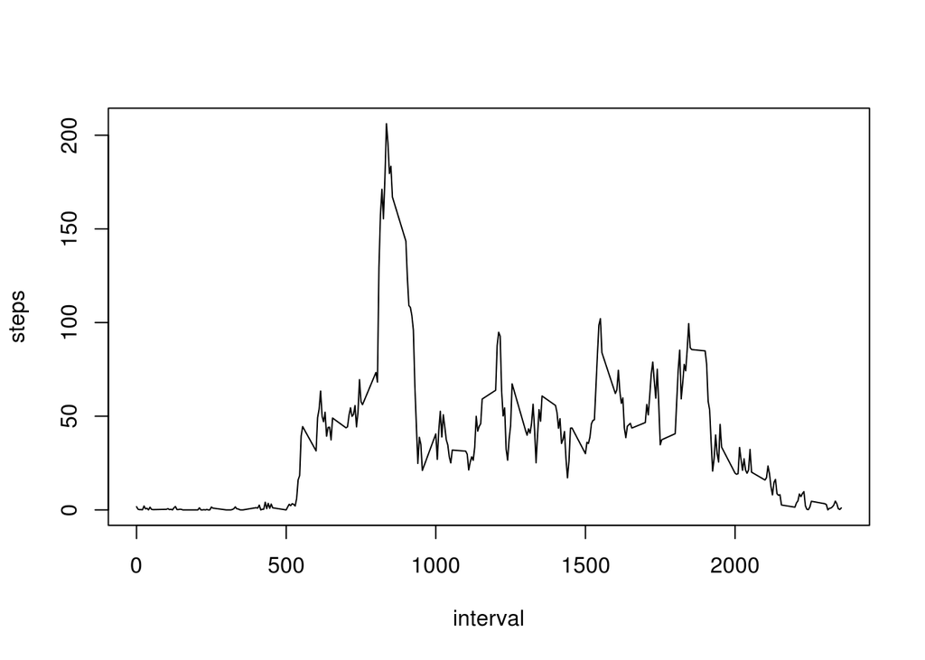

```r
stepsInterval <- aggregate(steps ~ interval, data = activity, FUN = mean)
plot(stepsInterval, type = "l")
```

**Which 5-minute interval, on average across all the days in the dataset, contains the maximum number of steps?**

```r
stepsInterval$interval[which.max(stepsInterval$steps)]
```

```
## [1] 835
```

## Imputing missing values

**Calculate and report the total number of missing values in the dataset (i.e. the total number of rows with NAs)**

```r
sum(is.na(activity))
```

```
## [1] 2304
```

**Devise a strategy for filling in all of the missing values in the dataset. The strategy does not need to be sophisticated. For example, you could use the mean/median for that day, or the mean for that 5-minute interval, etc.**

```r
acts <- merge(activity, stepsInterval, by = "interval", suffixes = c("", ".y"))
naval <- is.na(acts$steps)
acts$steps[naval] <- acts$steps.y[naval]
acts <- acts[, c(1:3)]
```

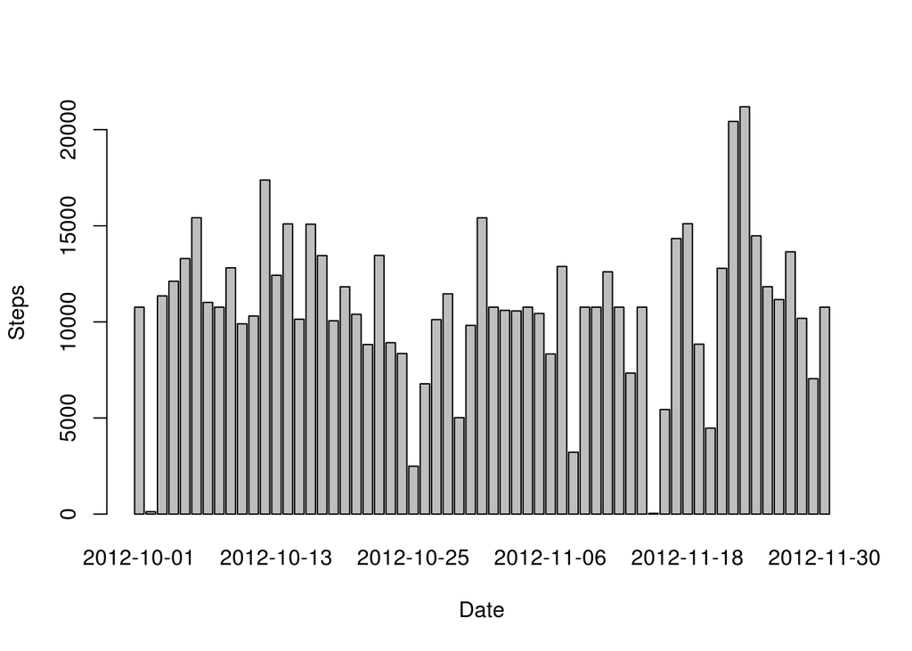

```r
stepsDate <- aggregate(steps ~ date, data = acts, FUN = sum)
barplot(stepsDate$steps, names.arg = stepsDate$date, xlab = "Date", ylab = "Steps")
```

**Calculate and report the mean and median total number of steps taken per day**

```r
mean(stepsPerDay$steps)
```

```
## [1] 10766
```

```r
median(stepsPerDay$steps)
```

```
## [1] 10765
```

## Are there differences in activity patterns between weekdays and weekends?

**Create a new factor variable in the dataset with two levels – “weekday” and “weekend” indicating whether a given date is a weekday or weekend day.**

```r
typeOfDays <- function(date) {
    if (weekdays(as.Date(date)) %in% c("Saturday", "Sunday")) {
        "weekend"
    } else {
        "weekday"
    }
}
acts$tdays <- as.factor(sapply(acts$date, typeOfDays))
```

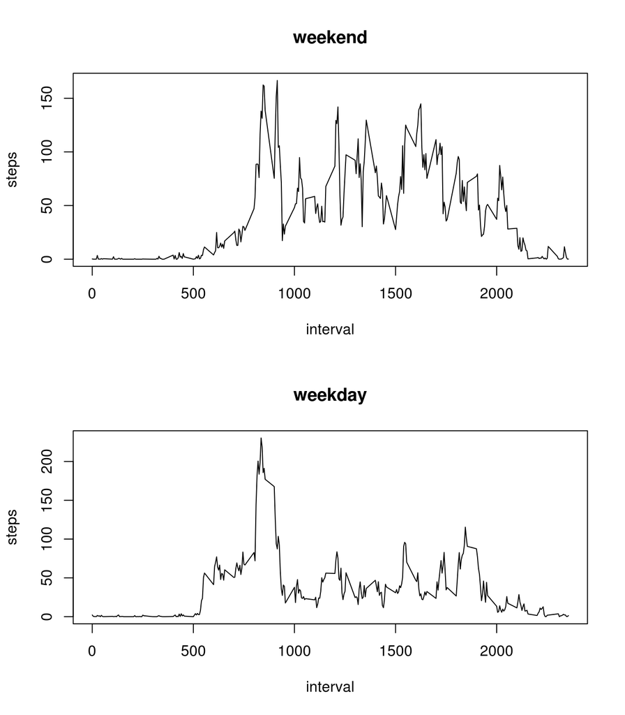

```r
par(mfrow = c(2, 1))
for(dtype in c("weekend", "weekday")) {
    stepsType <- aggregate(steps ~ interval, data = acts, subset = acts$tdays == dtype, FUN = mean)
    plot(stepsType, type = "l", main = dtype)
}
```